# Effects of Loan Features on Loan Status

## by Myra Lugwiri

## Investigation Overview

In this investigation I wanted to look at how the BorrowerAPR, BorrowerRate, IsBorrowerHomeowner and EmploymentStatus variables affect the LoanStatus of the loans taken.

## Dataset Overview

This dataset consists of 113,937 loans taken with 81 variables on each loan including loan amount, borrower rate (or interest rate), borrowerAPR, current loan status, borrower income, and many others. Over 10 variables were removed due to a lot of missing data.

## Distribution of LoanStatus

Most of the Loans taken a large number are of the current Loan Status. With Completed, Chargedoff and Defaulted following behind, the remaining Loan Statuses have extremely low numbers of Loans.

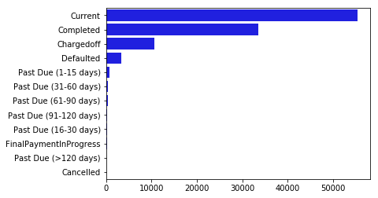

## LoanStatus vs EmploymentStatus

We have an interaction between the LoanStatus and EmploymentStatus, where more ideal EmploymentStatus which is employed has the highest number of loans whose LoanStatus is Current. And the LoanStatus Completed as expected has the highest number of Loans whose employmentStatus is Full-time. The other EmploymentStatuses have a small number of loans that have the remaining LoanStatuses.

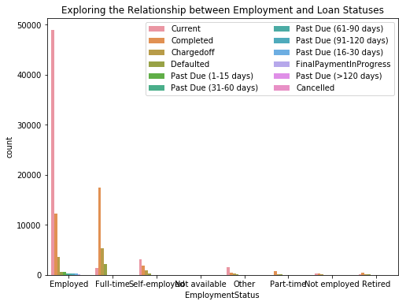

## LoanStatus vs IsBorrowerHomeowner

The Current LoanStatus has the highest number of loans whose individuals are homeowners where True indicating an individual is a homeowner. As The chargedoff LoanStatus has a large number of individuals who are not homeowners(False)as compared to those who are homeowners(True). From the exploration it seems individuals who are houseowners(True) have Current Loanstatus.

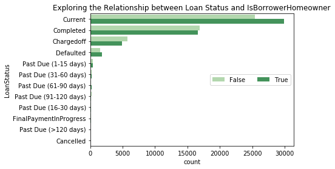

## LoanStatus by BorrowerAPR and BorrowerRate

A high BorrowerAPR and an individual who is not a houseowner(False) have a LoanStatus as expected of Past Due (>120 Days) that is higher than the individuals who are houseowners(True). It seems individuals who are houseowners(True) do not have a cancelled LoanStatus. Most of the LoanStatuses for individuals who are not houseowners(False) have a high BorrowerAPR which is expected but we have the Current and Completed LoanStatus for individuals who are not houseowners(False) to having a higher BorrowerAPR than those with houses.

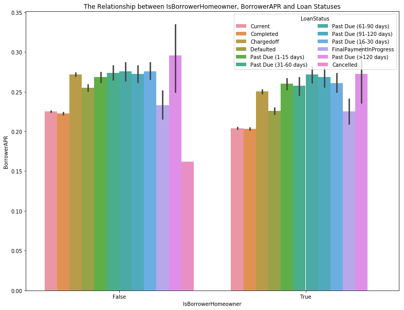

## BorrowerAPR vs BorrowerRate

Plotting all the BorrowerAPR and BorrowerRate data on a scatter plot it produces a linear relationship that exists between the 2 variables. Where an increase in BorrowerAPR we will have a positive increase in BorrowerRate.

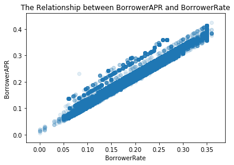

## BorrowerRate and BorrowerAPR by LoanStatus

### (Current, Completed, Chargedoff)

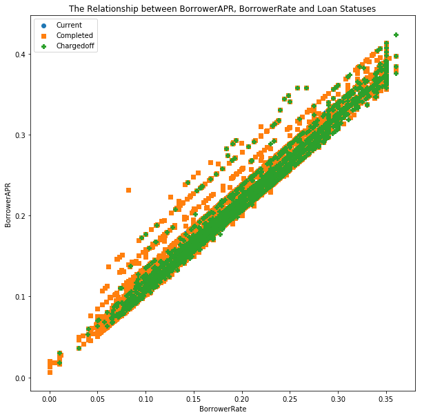

## BorrowerRate and BorrowerAPR by LoanStatus

### (Defaulted, Past Due (1-15 days), Past Due (31-60 days))

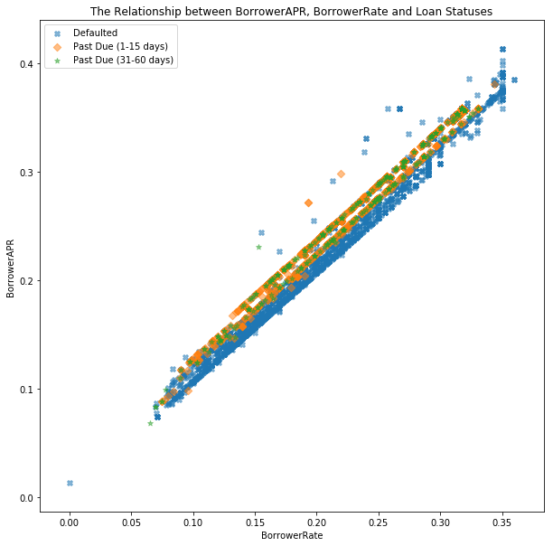

## Summary

> More favourable EmploymentStatuses such as Employed and Full-time have the highest number of loans with Current and Completed LoanStatus

> The LoanStatus is affected by the individual's IsBorrowerHomeowner Status where e.g Chargedoff loans a large number of the given loans are taken by individuals who are not houseowners

> Higher BorrowerAPR and BorrowerRate is associated with LoanStatus such as Past-Due(>120 Days) where the higher the BorrowerAPR and BorrowerRate the more the loans with unfavourable LoanStatuses

> The Analysis of the data had some columns which would have provided more insight but the columns had a lot of missing values hence were removed

> Further analysis needs to be done to better understand what other factors affect the LoanStatus.